# Analysis

### Project Introduction

**Background**

For my project, I decided to focus my efforts on better understanding the oil and gas industry’s “shale” well, which utilizes cutting edge engineering processes to generate large volumes of liquids. One of the more critical business practices in the energy sector is to be able to forecast or predict whether or not an oil and gas well when drilled will produce a significant amount of oil and in respect generate cash flow positive results. While the majority of oil and gas producers like BP, ExxonMobil, Shell, and Chevron have historically viewed this problem as a geological one, recently with the massive collection of historical well records big data has started to look at forecasting what the well’s initial production (IP) rate would look like given a wide variety of decisions that can be made by the producer.

While geology does matter and where the oil and gas well is drilled with respect to how “good” the rock quality is, utilizing big data and generating unique well features to forecast whether a well will come online with a poor, average, or good IP rate will be the new approach, as many producers are beginning to hire less geoscientists and instead scale up their data science departments. For this project I am looking to acquire a large sample size of different oil and gas well’s overall production results as well as many variables describing things like when they were drilled, who the producer was, what depth the well was drilled to, etc. Along with acquiring this data for different states (Texas, Colorado, New Mexico, North Dakota), I was given specifications for what the JP Morgan Commodity Research Group looks for when they are deciding in which well class they are looking to invest capital into, as certain IP ranges correspond to their definition of “investable” versus “non-investable”. With this idea, I will be looking to apply machine learning to predict this well performance classification.

**Workflow Steps**

For this project I will be focused on the following workflow steps:

**Project Goal | Oil & Gas Introduction**

Oil and gas wells have been drilled in the US since the mid 1850s, as they have continually been one of the better asset returns for investors since the commodity market really became a critical part of the economy. Investment companies or “producers” usually invest a significant amount of capital upfront to drill and “frac” the well, which allows fluids and specially “oil” to flow to the surface. The first indicator on how the oil and gas well will perform over its lifetime is the well’s “intial production” or IP rate, which measures the maximum observed monthly oil volume that was produced, as higher IP rates tend to point toward better investment returns over the next decade or so of that well’s life. The chart on the right visually describes what we need to identify as the well’s IP rate for this well investment predication problem. Now that we have an idea on what metric we are looking to classify each oil and gas well by let’s get into the machine learning worflow by starting with obtaining data through data acquistion.

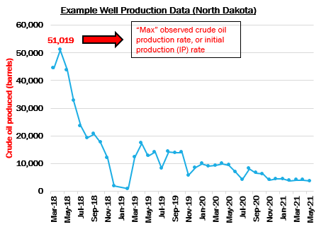

Figure 1.

# Analysis

**Step 1: Drilling Data**

Now that we have a general idea of what we are trying to predict, let’s take a look at the first step of any data science problem which is obtaining data. Before we take a look at any data, let’s bring in the necessary R packages and functions that will be useful throughout the workflow:

```r
# LOAD NEEEDED PACKAGES, FUNCTIONS, COLOR SCHEMES ============================================================================
library("caret")
library("naivebayes")
library("dplyr")
library("ggplot2")
library("psych")
library("pscl")
library("leaflet.extras")
library("magrittr")
library("plumber")
library("geosphere")
library("NISTunits")
library("class")
library("fields")
library("randomcoloR")
library("svMisc")
library("timeDate")
library("RODBC")
library("dplyr")
library("ggplot2")
library("class")
library("tidyr")
library("aRpsDCA")
library("ggExtra")
library("gridExtra")
library("RODBCext")
library("MASS")
library("ggpubr")
library("grid")
library("caret")
library("fitdistrplus")
library("tseries")
library("forecast")
library("mgcv")
library("zoo")
library("xlsx")
library("EnvStats")
library("maptools")
library("viridis")
library("leaflet")
library("aRpsDCA")
library("nnet")
library("RSNNS")
library("svMisc")
library("timeDate")
library("RODBC")
library("dplyr")
library("ggplot2")
library("class")
library("ggmap")
library("tidyr")
library("aRpsDCA")
library("ggExtra")
library("gridExtra")
library("RODBCext")
library("MASS")
library("ggpubr")
library("grid")
library("fitdistrplus")
library("tseries")
library("forecast")
library("mgcv")
library("lubridate")
library("Hmisc")
library("zoo")
library("xlsx")
library("EnvStats")
library("maptools")
library("viridis")
library("leaflet")
library("jsonlite")
library("stringr")
library("RODBC")
library("dplyr")
library("ggplot2")
library("class")
library("ggmap")
library("tidyr")
library("aRpsDCA")
library("ggExtra")
library("gridExtra")
library("RODBCext")
library("MASS")
library("ggpubr")
library("grid")
library("plyr")
library("plotly")
library("RColorBrewer")
library("rpart")
library("rattle")
library("rpart.plot")
library("xlsx")
library("flexdashboard")
library("DT")
library("colorRamps")
library("readxl")
library("astsa")
library("shiny")
library("DataExplorer")
library("class")
library("e1071")
library("dummies")
library("randomForest")

set.seed(1234)
COLOR <- distinctColorPalette(12)

write.excel <- function(x,row.names=FALSE,col.names=TRUE,...) {
  write.table(x,"clipboard",sep="\t",row.names=row.names,col.names=col.names,...)
}
```

Great, now we have some R packages and a few functions and color palettes that will help with our visualization efforts! Now that we can call on a variety of different functions, let’s begin by loading in some of the government oil & gas data that has already been stored on a few of my local SQL servers. While I would love to showcase how I was able to scrape some of these datasets and load them into SQL, unfortunately due to a few of my personal company signed non-disclosures, this won’t be possible. First, let’s bring in some of the “drilling” or variables describing how the well was drilled into the subsurface before we take a look at a few other data pieces:

```r
# LOAD SQL DRILLING DATA ============================================================================

# CONNECT TO LOCAL SERVER
conn1 <-
  odbcDriverConnect(
    'driver=ODBC Driver 11 for SQL Server;server=server-prod18.be.local\\eifi_prod,3145;database=BentekEnergyDW; trusted_connection=yes'
  )

# SQL QUERY BRINGING IN DRILLING VARIABLES
# FILTER BASED ON STATES --> ND, CO, TX, NM
# SPUD DATES AFTER JAN 2013

DRILLING <- "SELECT StateName, CountyName, API, WellOrientation, SpudDate,
ReleaseDate, DrillerName, PowerType, HPDRAW, ProposedTotalDepth, SurfaceLat, SurfaceLong,
BottomHoleLat, BottomHoleLong
  FROM [BentekEnergyDW].[GasProduction].[tblEnverusRigDataPLSDB]
  WHERE StateCode IN ('ND','CO','TX','NM')
  AND SpudDate >= '2013-01-01'
  ORDER BY SpudDate DESC"
DRILLING <- sqlExecute(conn1, DRILLING, fetch = TRUE)
Drilling_Data <- DRILLING

# CLEAN DRILLING DATA W/ INITIAL WRANGLING ============================================================================

Drilling_Data$API <- gsub("-", "", Drilling_Data$API)
Drilling_Data$API <- gsub("[^0-9.-]", "", Drilling_Data$API)
Drilling_Data$API <- as.character(Drilling_Data$API)

Drilling_Data$SpudDate <- as.Date(Drilling_Data$SpudDate)
Drilling_Data$ReleaseDate <- as.Date(Drilling_Data$ReleaseDate)

# WE NEED TO AGGREGATE HERE, AS SOME INDIVIIDUAL WELLS HAVE MULTIPLE RECORDS
# WE ONLY NEED ONE VARIALBE PER WELL, ALSO IDENTIFIED BY THE API NUMBER
DRILL_SPUD <- aggregate(Drilling_Data$SpudDate, by = list(Drilling_Data$API), FUN = max)
DRILL_RELEASE <- aggregate(Drilling_Data$ReleaseDate, by = list(Drilling_Data$API), FUN = max)
DRILL_SURFACE_LAT <- aggregate(Drilling_Data$SurfaceLat, by = list(Drilling_Data$API), FUN = max)
DRILL_SURFACE_LONG <- aggregate(Drilling_Data$SurfaceLong, by = list(Drilling_Data$API), FUN = max)
DRILL_BOTTOM_LAT <- aggregate(Drilling_Data$BottomHoleLat, by = list(Drilling_Data$API), FUN = max)
DRILL_BOTTOM_LONG <- aggregate(Drilling_Data$BottomHoleLong, by = list(Drilling_Data$API), FUN = max)
DRILL_ORIENTATION <- aggregate(Drilling_Data$WellOrientation, by = list(Drilling_Data$API), FUN = first)
DRILL_PROPOSED_DEPTH <- aggregate(Drilling_Data$ProposedTotalDepth, by = list(Drilling_Data$API), FUN = max)
DRILL_POWER_TYPE <- aggregate(Drilling_Data$PowerType, by = list(Drilling_Data$API), FUN = first)
DRILL_DRILLER <- aggregate(Drilling_Data$DrillerName, by = list(Drilling_Data$API), FUN = first)
DRILL_HPDRAW <- aggregate(Drilling_Data$HPDRAW, by = list(Drilling_Data$API), FUN = max)
DRILL_STATE <- aggregate(Drilling_Data$StateName, by = list(Drilling_Data$API), FUN = first)

# CREATE FINAL DATAFRAME FOR DRILLED DATA
Drilling_Data <- data.frame(API = DRILL_SPUD$Group.1, SpudDate = DRILL_SPUD$x, ReleaseDate = DRILL_RELEASE$x,
                            SurfaceLat = DRILL_SURFACE_LAT$x, SurfaceLong = DRILL_SURFACE_LONG$x, BottomLat = DRILL_BOTTOM_LAT$x,
                            BottomLong = DRILL_BOTTOM_LONG$x, Orientation = DRILL_ORIENTATION$x,
                            ProposedDepth = DRILL_PROPOSED_DEPTH$x, Power_Type = DRILL_POWER_TYPE$x, Driller_Name = DRILL_DRILLER$x, HP_Draw = DRILL_HPDRAW$x)

# CLEAN UP UNWANTED DATA FRAMES, VECTORS, ETC
rm(DRILL_SPUD, DRILL_RELEASE, DRILL_SURFACE_LAT, DRILL_SURFACE_LONG, DRILL_BOTTOM_LAT, DRILL_BOTTOM_LONG, DRILL_ORIENTATION, DRILL_PROPOSED_DEPTH,
   DRILL_POWER_TYPE, DRILL_DRILLER, DRILL_HPDRAW, DRILL_STATE, DRILLING)

summary(Drilling_Data)
```

```
     API               SpudDate           ReleaseDate           SurfaceLat
 Length:114552      Min.   :2013-01-01   Min.   :2013-01-05   Min.   : 0.00
 Class :character   1st Qu.:2014-04-28   1st Qu.:2014-05-10   1st Qu.:31.19
 Mode  :character   Median :2016-02-21   Median :2016-02-10   Median :32.09
                    Mean   :2016-08-11   Mean   :2016-08-13   Mean   :33.94
                    3rd Qu.:2018-10-27   3rd Qu.:2018-10-22   3rd Qu.:33.58
                    Max.   :2021-12-30   Max.   :2021-09-28   Max.   :49.00
                                         NA's   :948
  SurfaceLong        BottomLat       BottomLong      Orientation
 Min.   :-109.05   Min.   : 0.00   Min.   :-119.29   Length:114552
 1st Qu.:-103.45   1st Qu.:31.11   1st Qu.:-103.45   Class :character
 Median :-102.04   Median :32.07   Median :-102.01   Mode  :character
 Mean   :-101.41   Mean   :33.53   Mean   :-100.49
 3rd Qu.: -99.48   3rd Qu.:33.47   3rd Qu.: -99.38
 Max.   :   0.00   Max.   :89.52   Max.   :   0.00
                   NA's   :2       NA's   :2
 ProposedDepth    Power_Type        Driller_Name          HP_Draw
 Min.   :    0   Length:114552      Length:114552      Min.   :   0
 1st Qu.: 8500   Class :character   Class :character   1st Qu.:1000
 Median :10545   Mode  :character   Mode  :character   Median :1500
 Mean   :10437                                         Mean   :1240
 3rd Qu.:12080                                         3rd Qu.:1500
 Max.   :85280                                         Max.   :4500
```

While the drilling information is focused on the physical drilling of the well and its subsurface information, the “frac” data will focus on how the well was hydraulically fractured or “frac’ed”, which is a commonly used term in media and industry. After an oil and gas well is drilled, the producer will inject the well with fluids to stimulate the well and hopefully improve the chance that the well produces a large amount of oil and has a relatively strong IP rate. Looking at the code below, we can bring in this frac database for wells and generate a similar data wrangling technique to get the final frac dataframe ready to be joined onto the drilling and production dataframes:

```r
# LOAD SQL FRAC FOCUS DATA ============================================================================

# CONNECT TO LOCAL SERVER
conn2 <-
  odbcDriverConnect(
    'Driver=ODBC Driver 11 for SQL Server;server=server-dev18.be.local;database=FracFocusRegistry; Uid=andrew_cooper; Pwd=aWll!&15lm; trusted_connection=yes'
  )

# SQL QUERY BRINGING IN DRILLING VARIABLES
# FILTER BASED ON STATES --> ND, CO, TX, NM
# JOB END DATES AFTER JAN 2013

FRAC_FOCUS <- "SELECT [JobStartDate]
      ,[JobEndDate]
      ,[APINumber]
      ,[TotalBaseWaterVolume]
      ,[StateName]
  FROM [FracFocusRegistry].[dbo].[RegistryUpload]
  WHERE StateName IN ('North Dakota','ND','Texas','TX','New Mexico','NM','Colorado','CO')
  AND JobEndDate >= '2013-01-01'
  ORDER BY JobEndDate DESC"
FRAC_FOCUS <- sqlExecute(conn2, FRAC_FOCUS, fetch = TRUE)
FracFocus_Data <- FRAC_FOCUS

# CLEAN FRAC DATA W/ INITIAL WRANGLING ============================================================================

FracFocus_Data$APINumber <- as.character(FracFocus_Data$APINumber)
FracFocus_Data$APINumber <- gsub("0000", "", FracFocus_Data$APINumber)
FracFocus_Data$APINumber <- gsub("0001", "", FracFocus_Data$APINumber)
FracFocus_Data$APINumber <- gsub("[^0-9.-]", "", FracFocus_Data$APINumber)
FracFocus_Data$APINumber <- as.character(FracFocus_Data$APINumber)

FracFocus_Data$JobStartDate <- as.Date(FracFocus_Data$JobStartDate)
FracFocus_Data$JobEndDate <- as.Date(FracFocus_Data$JobEndDate)

# WE NEED TO AGGREGATE HERE, AS SOME INDIVIIDUAL WELLS HAVE MULTIPLE RECORDS
# WE ONLY NEED ONE VARIALBE PER WELL, ALSO IDENTIFIED BY THE API NUMBER
FRAC_JOB_END <- aggregate(FracFocus_Data$JobEndDate, by = list(FracFocus_Data$APINumber), FUN = max)
FRAC_JOB_START <- aggregate(FracFocus_Data$JobEndDate, by = list(FracFocus_Data$APINumber), FUN = max)
FRAC_BASE_WATER_VOLUME <- aggregate(FracFocus_Data$TotalBaseWaterVolume, by = list(FracFocus_Data$APINumber), FUN = max)
FRAC_STATE <- aggregate(FracFocus_Data$StateName, by = list(FracFocus_Data$APINumber), FUN = first)

# CREATE FINAL DATAFRAME FOR FRAC DATA
FracFocus_Data <- data.frame(API = FRAC_STATE$Group.1, JobStart_Date = FRAC_JOB_START$x,
                             JobEnd_Date = FRAC_JOB_END$x, BaseWater_Volume = FRAC_BASE_WATER_VOLUME$x)

# CLEAN UP UNWANTED DATA FRAMES, VECTORS, ETC
rm(FRAC_FOCUS, FRAC_JOB_END, FRAC_JOB_START, FRAC_BASE_WATER_VOLUME, FRAC_STATE)

summary(FracFocus_Data)
```

```
     API            JobStart_Date         JobEnd_Date
 Length:96758       Min.   :2013-01-01   Min.   :2013-01-01
 Class :character   1st Qu.:2014-05-09   1st Qu.:2014-05-09
 Mode  :character   Median :2016-03-14   Median :2016-03-14
                    Mean   :2016-08-15   Mean   :2016-08-15
                    3rd Qu.:2018-10-12   3rd Qu.:2018-10-12
                    Max.   :3012-04-01   Max.   :3012-04-01

 BaseWater_Volume
 Min.   :        0
 1st Qu.:  1745856
 Median :  5855556
 Mean   :  7887264
 3rd Qu.: 11778980
 Max.   :592516724
 NA's   :7
```

```r
# LOAD SQL PRODUCTION DATA ============================================================================

# CONNECT TO LOCAL SERVER
conn4 <-
  odbcDriverConnect(
    'driver=ODBC Driver 11 for SQL Server;server=prodsql01.be.local;database=GasProductionRawData;Uid=andrew_cooper; Pwd=aIll!&15lm; trusted_connection=yes'
  )

# SQL QUERY BRINGING IN DRILLING VARIABLES
# FILTER BASED ON STATES --> ND, CO, TX, NM
# FIRST PRODUCTION DATES AFTER JAN 2013

PRODUCTION <- "SELECT PROD_DATE, LIQ, GAS, WATER, ProdType, BentekState, BentekCounty, ApiNo, Reservoir, DrillType, CurrOperName, TotalDepth,
    FirstProdDate, Latitude, Longitude, OilGravity FROM [GasProductionRawData].[dbo].[tblPden_Prod] t1
    FULL OUTER JOIN [GasProduction].[GasProduction].[tblWells] t2 ON t1.ENTITY_ID = t2.EntityID
    WHERE BentekState IN ('ND','TX','NM','CO')
    AND FirstProdDate >= '2013-01-01'"
PRODUCTION <- sqlExecute(conn4, PRODUCTION, fetch = TRUE)
Production_Data <- PRODUCTION

# CLEAN PRODUCTION DATA W/ INITIAL WRANGLING ============================================================================

Production_Data$ApiNo <- as.character(Production_Data$ApiNo)
Production_Data$ApiNo <- gsub("[^0-9.-]", "", Production_Data$ApiNo)
Production_Data$ApiNo <- gsub("0000", "", Production_Data$ApiNo)
Production_Data$ApiNo <- as.character(Production_Data$ApiNo)

Production_Data$PROD_DATE <- as.Date(Production_Data$PROD_DATE)
Production_Data$FirstProdDate <- as.Date(Production_Data$FirstProdDate)

# WE NEED TO AGGREGATE HERE, AS SOME INDIVIIDUAL WELLS HAVE MULTIPLE RECORDS
# WE ONLY NEED ONE VARIALBE PER WELL, ALSO IDENTIFIED BY THE API NUMBER
PROD_LAT <- aggregate(Production_Data$Latitude, by = list(Production_Data$ApiNo), FUN = max)
PROD_LONG <- aggregate(Production_Data$Longitude, by = list(Production_Data$ApiNo), FUN = max)
PROD_GAS <- aggregate(Production_Data$GAS, by = list(Production_Data$ApiNo), FUN = max)
PROD_OIL <- aggregate(Production_Data$LIQ, by = list(Production_Data$ApiNo), FUN = max)
PROD_WATER <- aggregate(Production_Data$WATER, by = list(Production_Data$ApiNo), FUN = max)
PROD_FIRSTPROD <- aggregate(Production_Data$FirstProdDate, by = list(Production_Data$ApiNo), FUN = max)
PROD_PRODTYPE <- aggregate(Production_Data$ProdType, by = list(Production_Data$ApiNo), FUN = first)
PROD_DRILLTYPE <- aggregate(Production_Data$DrillType, by = list(Production_Data$ApiNo), FUN = first)
PROD_DEPTH <- aggregate(Production_Data$TotalDepth, by = list(Production_Data$ApiNo), FUN = max)
PROD_OPERATOR <- aggregate(Production_Data$CurrOperName, by = list(Production_Data$ApiNo), FUN = first)
PROD_RESERVOIR <- aggregate(Production_Data$Reservoir, by = list(Production_Data$ApiNo), FUN = max)
PROD_OIL_GRAVITY <- aggregate(Production_Data$OilGravity, by = list(Production_Data$ApiNo), FUN = max)
PROD_STATE <- aggregate(Production_Data$BentekState, by = list(Production_Data$ApiNo), FUN = first)

# CREATE FINAL DATAFRAME FOR PRODUCTION DATA
Production_Data <- data.frame(API = PROD_LAT$Group.1, Lat = PROD_LAT$x, Long = PROD_LONG$x, ProdState = PROD_STATE$x,
                                      Gas_IP = PROD_GAS$x, Oil_IP = PROD_OIL$x, Water_IP = PROD_WATER$x,
                                      FirstProdDate = PROD_FIRSTPROD$x, Prod_Type = PROD_PRODTYPE$x,
                                      Drill_Type = PROD_DRILLTYPE$x, Depth = PROD_DEPTH$x, Operator = PROD_OPERATOR$x,
                                      Reservoir = PROD_RESERVOIR$x, Oil_Gravity = PROD_OIL_GRAVITY$x)

# CLEAN UP UNWANTED DATA FRAMES, VECTORS, ETC
rm(PRODUCTION, PROD_LAT, PROD_LONG, PROD_GAS, PROD_OIL, PROD_WATER, PROD_FIRSTPROD, PROD_DRILLTYPE, PROD_PRODTYPE,
   PROD_DEPTH, PROD_OPERATOR, PROD_RESERVOIR, PROD_OIL_GRAVITY, PROD_STATE)

summary(Production_Data)
```

```
     API                 Lat             Long          ProdState
 Length:115650      Min.   :26.02   Min.   :-109.05   Length:115650
 Class :character   1st Qu.:31.08   1st Qu.:-103.39   Class :character
 Mode  :character   Median :32.07   Median :-101.94   Mode  :character
                    Mean   :33.85   Mean   :-101.37
                    3rd Qu.:33.57   3rd Qu.: -99.19
                    Max.   :49.00   Max.   : -93.58
                    NA's   :12      NA's   :12
     Gas_IP            Oil_IP          Water_IP        FirstProdDate
 Min.   :      0   Min.   :     0   Min.   :       0   Min.   :2013-01-01
 1st Qu.:   4225   1st Qu.:  1867   1st Qu.:    3851   1st Qu.:2014-05-01
 Median :  19662   Median : 10646   Median :   13826   Median :2016-01-01
 Mean   :  38511   Mean   : 14176   Mean   :   34701   Mean   :2016-06-30
 3rd Qu.:  44914   3rd Qu.: 21885   3rd Qu.:   37844   3rd Qu.:2018-09-01
 Max.   :1539737   Max.   :334209   Max.   :35386581   Max.   :2021-06-01
 NA's   :7067      NA's   :14947    NA's   :8525
  Prod_Type          Drill_Type            Depth         Operator
 Length:115650      Length:115650      Min.   :  124   Length:115650
 Class :character   Class :character   1st Qu.: 9580   Class :character
 Mode  :character   Mode  :character   Median :14454   Mode  :character
                                       Mean   :13507
                                       3rd Qu.:18060
                                       Max.   :36600
                                       NA's   :198
  Reservoir          Oil_Gravity
 Length:115650      Min.   : 1.00
 Class :character   1st Qu.:39.30
 Mode  :character   Median :42.00
                    Mean   :42.99
                    3rd Qu.:46.10
                    Max.   :99.00
                    NA's   :13691
```

```r
####################################################################################################
```

Wrapping up this lengthy data acquisition section, it looks like we have around 115,650 individual well records that have needed production information for us to analyze which well’s performed better than others, all depending on the oil IP rate output. So here we have 3 dataframes all sharing a common identification key seen as the “API” number meaning we can perform some sort of “join” function to connect all the possible drilling, frac, and production variables to their associated API number. This API number is a unique government issued ID number to make sure each well has a way of being uniquely identified across different states. We can join these dataframes together and this will be our final dataset that will be processed a little further and eventually used in our exploratory data analysis report:

```r
# LET'S MAKE SURE THIS API NUMBER IS NUMERIC, SO THE JOIN FUNCTION WILL WORK
Drilling_Data$API <- as.numeric(Drilling_Data$API)
FracFocus_Data$API <- as.numeric(FracFocus_Data$API)
Production_Data$API <- as.numeric(Production_Data$API)

# WE WANT TO SEE HOW MANY DRILLING & FRAC RECORDS CAN BE JOINED TO THE PRODUCTION DATASET, AS WE NEED TO USE PRODUCTION VARIABLES TO DEFINE THE PREDICTION OBSERVATION OF INTEREST
FINAL_DATA_JOIN <- left_join(Production_Data, Drilling_Data, by = "API")
FINAL_DATA_JOIN <- left_join(FINAL_DATA_JOIN, FracFocus_Data, by = "API")

# FINAL STRUCTURE OF DATAFRAME
str(FINAL_DATA_JOIN)
```

```
'data.frame':   115650 obs. of  28 variables:
 $ API             : num  0 3 3 3 3 ...
 $ Lat             : num  NA 33 32.5 32.5 32.8 ...
 $ Long            : num  NA -104 -104 -104 -104 ...
 $ ProdState       : chr  "TX" "NM" "NM" "NM" ...
 $ Gas_IP          : num  NA NA 4222 NA NA ...
 $ Oil_IP          : num  NA 14649 374 NA 1448 ...
 $ Water_IP        : num  NA NA 3410 1330 6120 ...
 $ FirstProdDate   : Date, format: "2021-05-01" "2017-12-01" ...
 $ Prod_Type       : chr  "OIL" "OIL" "GAS" "OIL" ...
 $ Drill_Type      : chr  "V" "H" "V" "V" ...
 $ Depth           : num  NA 8255 11075 12339 3562 ...
 $ Operator        : chr  "ENERVEST OPERATING, LLC" "MACK ENERGY CORPORATION" "ASCENT OIL & GAS CORP." "JUDAH OIL LLC" ...
 $ Reservoir       : chr  "WOLFCAMP" "SAN ANDRES" "BONE SPRING" "DELAWARE" ...
 $ Oil_Gravity     : num  NA 35.2 40 39.6 NA NA NA NA 39.3 39.5 ...
 $ SpudDate        : Date, format: NA NA ...
 $ ReleaseDate     : Date, format: NA NA ...
 $ SurfaceLat      : num  NA NA NA NA NA NA NA NA NA NA ...
 $ SurfaceLong     : num  NA NA NA NA NA NA NA NA NA NA ...
 $ BottomLat       : num  NA NA NA NA NA NA NA NA NA NA ...
 $ BottomLong      : num  NA NA NA NA NA NA NA NA NA NA ...
 $ Orientation     : chr  NA NA NA NA ...
 $ ProposedDepth   : int  NA NA NA NA NA NA NA NA NA NA ...
 $ Power_Type      : chr  NA NA NA NA ...
 $ Driller_Name    : chr  NA NA NA NA ...
 $ HP_Draw         : int  NA NA NA NA NA NA NA NA NA NA ...
 $ JobStart_Date   : Date, format: NA NA ...
 $ JobEnd_Date     : Date, format: NA NA ...
 $ BaseWater_Volume: num  NA NA NA NA NA NA NA NA NA NA ...
```

So to finalize our thoughts here, we now have a dataframe that has 115,650 wells with production data and relatively speaking 27 descriptive variables that accompany each API number. This data will be processed in our next blog section a little further, and we will be using some industry definitions provided by JP Morgan’s Commodity Investment Group to define whether each well would be investable or not depending on its maximum observed monthly oil rate. The goal would be to utilize all these well’s variables to separate the stronger performing wells based on the combination of different drilling, frac, and production information.

# Analysis

### Background

As shown in the introduction section, the IP rate is a the maximum observed monthly oil production reported by the well, and higher IP rates tend to correlate strongly to well’s that produce more total oil over the lifetime of its duration. For this final processing, we need to define our target observation that we are trying to use machine learning algorithms to predict. First step will be to remove any data that doesn’t have an oil IP rate, as we won’t know what type of well performance category to expect without this information. Next, we define the predictor variable as “TargetWellPerformance”, and these boundaries were provided to me by an outside industry expert who has experience defining which wells to invest capital in based on this IP category prediction theme:

```r
# TARGET VARIABLE ANALYSIS ##############################################################################

# IF OIL IP HAS NULL VALUE, STATE DIDN'T REPORT DATA, SO WE NEED TO REMOVE AS A MISSING TARGET VALUE
FINAL_DATA_JOIN <- subset(FINAL_DATA_JOIN, is.na(Oil_IP) == F)
FINAL_DATA_JOIN$TargetWellPerformance = NA

# THESE DEFINITIONS WERE PROVIDED BY INDUSTRY CONTACT FOR HOW COMMODITY INVESTMENT FIRMS DETERMINE WHICH WELL HAS A POOR, AVERAGE, OR GOOD RETURN
# IN THE OIL & GAS SECTOR, A "POOR" PERFORMING OIL WELL HAS INITIAL PRODUCTION OF <= 15,000 BARRELS
# IN THE OIL & GAS SECTOR, A "GREAT" PERFORMING OIL WELL HAS INITIAL PRODUCTION OF > 15,000 BARRELS

FINAL_DATA_JOIN_A <- subset(FINAL_DATA_JOIN, Oil_IP <= 15000)
FINAL_DATA_JOIN_A$TargetWellPerformance = 0

FINAL_DATA_JOIN_B <- subset(FINAL_DATA_JOIN, Oil_IP > 15000)
FINAL_DATA_JOIN_B$TargetWellPerformance = 1

FINAL_DATA_JOIN <- rbind(FINAL_DATA_JOIN_A, FINAL_DATA_JOIN_B)
rm(FINAL_DATA_JOIN_A, FINAL_DATA_JOIN_B)

summary(as.factor(FINAL_DATA_JOIN$TargetWellPerformance))
```

```
    0     1
61024 39679
```

So we now have a relatively balanced amount of well’s that we will look to split into a training and testing subset to predict which category each well falls into based on a combination of many the well’s engineering combinations. This dataset will now be used as an input for our next blog post focused on exploratory data analysis where some of these variables will be analyzed in more depth.

# Analysis

### Background

This next post will focus on diving into exploratory data analysis before starting to look at any sort of feature engineering. The goal of EDA is to understand some of the distributions, missing data counts, and other critical descriptive analytics that might be worth taking note of before model building. First, we will look at understanding the numeric variables distributions and missing counts, the categorical frequency counts, date time variable ranges, and finally plot some of the geographic information to make sure our data is confined inside Texas, North Dakota, New Mexico, and Colorado:

```r
# EXPLORATORY ANALYSIS ##############################################################################

# NUMERIC VARIABLES
Hmisc::describe(FINAL_DATA_JOIN$Water_IP)
```

```
FINAL_DATA_JOIN$Water_IP
       n  missing distinct     Info     Mean      Gmd      .05      .10
   96693     4010    49278        1    35953    48937       71      544
     .25      .50      .75      .90      .95
    4255    14591    39487    77587   114803

lowest :        0        1        2        3        4
highest: 14161147 15248883 15248884 22323952 35386581

0 (95811, 0.991), 5e+05 (638, 0.007), 1e+06 (100, 0.001), 1500000 (54, 0.001),
2e+06 (38, 0.000), 2500000 (17, 0.000), 3e+06 (7, 0.000), 3500000 (9, 0.000),
4e+06 (3, 0.000), 4500000 (4, 0.000), 5e+06 (4, 0.000), 5500000 (1, 0.000),
6500000 (1, 0.000), 7e+06 (1, 0.000), 1.4e+07 (1, 0.000), 1.5e+07 (2, 0.000),
22500000 (1, 0.000), 35500000 (1, 0.000)

For the frequency table, variable is rounded to the nearest 500000
```

```r
Hmisc::describe(FINAL_DATA_JOIN$Gas_IP)
```

```
FINAL_DATA_JOIN$Gas_IP
       n  missing distinct     Info     Mean      Gmd      .05      .10
   97152     3551    51559    0.999    34035    42711      0.0     96.1
     .25      .50      .75      .90      .95
  3893.8  18471.0  41831.5  82740.8 125072.3

lowest :       0       1       2       3       4
highest:  925642  955210 1014481 1154167 1539737
```

```r
Hmisc::describe(FINAL_DATA_JOIN$Oil_Gravity)
```

```
FINAL_DATA_JOIN$Oil_Gravity
       n  missing distinct     Info     Mean      Gmd      .05      .10
   92927     7776     1102    0.999    42.37     7.91     32.0     34.8
     .25      .50      .75      .90      .95
    39.0     41.6     45.0     52.1     56.4

lowest :  1.0  1.1  1.2  1.3  1.9, highest: 95.9 96.0 96.7 98.0 99.0
```

```r
Hmisc::describe(FINAL_DATA_JOIN$Total_Fluid)
```

[output not shown]

```r
Hmisc::describe(FINAL_DATA_JOIN$Total_Proppant)
```

[output not shown]

```r
Hmisc::describe(FINAL_DATA_JOIN$BaseWater_Volume)
```

```
FINAL_DATA_JOIN$BaseWater_Volume
       n  missing distinct     Info     Mean      Gmd      .05      .10
   75844    24859    73097        1  8436562  8086267    91224   482293
     .25      .50      .75      .90      .95
 2261455  6756015 12481949 19447519 22783739

lowest :         0         1        24        71       100
highest: 156040971 201439580 219295956 349698468 472444086
```

```r
Hmisc::describe(FINAL_DATA_JOIN$Depth)
```

```
FINAL_DATA_JOIN$Depth
       n  missing distinct     Info     Mean      Gmd      .05      .10
  100506      197    20569        1    13764     6559     3200     4994
     .25      .50      .75      .90      .95
    9974    14960    18386    20747    21358

lowest :   124   127   129   132   148, highest: 28380 32384 35145 35927 36600
```

```r
Hmisc::describe(FINAL_DATA_JOIN$ProposedDepth)
```

```
FINAL_DATA_JOIN$ProposedDepth
       n  missing distinct     Info     Mean      Gmd      .05      .10
   84796    15907     9473    0.999    10558     3941     4400     5700
     .25      .50      .75      .90      .95
    9000    10662    12000    15000    17324

lowest :     0   300   400   425   450, highest: 25300 26000 26174 27000 28010
```

```r
Hmisc::describe(FINAL_DATA_JOIN$HP_Draw)
```

```
FINAL_DATA_JOIN$HP_Draw
       n  missing distinct     Info     Mean      Gmd      .05      .10
   84796    15907       65    0.811     1266    414.8      450      600
     .25      .50      .75      .90      .95
    1000     1500     1500     1500     1500

lowest :    0  100  150  180  200, highest: 1999 2000 2300 2500 3000
```

```r
# CHARACTER VARIABLES
summary(as.factor(FINAL_DATA_JOIN$Prod_Type))
```

```
         CBM CONFIDENTIAL          GAS          OIL      WTR INJ
          13            2        11787        88894            7
```

```r
summary(as.factor(FINAL_DATA_JOIN$Drill_Type))
```

```
    D     H     V
 3752 67974 28977
```

```r
summary(as.factor(FINAL_DATA_JOIN$Operator))
```

```
                       EOG RESOURCES, INC.
                                      4984
            PIONEER NATURAL RES. USA, INC.
                                      4066
                          XTO ENERGY, INC.
                                      2839
                         COG OPERATING LLC
                                      2633
                       DIAMONDBACK E&P LLC
                                      2364
                 CHESAPEAKE OPERATING, LLC
                                      2204
                        APACHE CORPORATION
                                      2071
                          KERR-MCGEE CORP.
                                      1703
         BURLINGTON RESOURCES OIL & GAS CO
                                      1678
                       MARATHON OIL EF LLC
                                      1571
                  DEVON ENERGY CORPORATION
                                      1547
           WHITING OIL AND GAS CORPORATION
                                      1460
                        NOBLE ENERGY, INC.
                                      1442
                     CHEVRON, U.S.A., INC.
                                      1311
                          OVINTIV USA INC.
                                      1291
               CONTINENTAL RESOURCES, INC.
                                      1256
                       OXY, U. S. A., INC.
                                      1170
           HESS BAKKEN INVESTMENTS II, LLC
                                      1165
                            PDC ENERGY INC
                                      1145
                       SN EF MAVERICK, LLC
                                      1127
```

[output cut: 145 more lines]

```
                                       197
                       CAERUS PICEANCE LLC
                                       196
                       FIREBIRD ENERGY LLC
                                       193
                   LONESTAR OPERATING, LLC
                                       187
                       SEA EAGLE FORD, LLC
                                       180
                    BTA OIL PRODUCERS, LLC
                                       178
                                   (Other)
                                     26857
                                      NA's
                                         1
```

```r
summary(as.factor(FINAL_DATA_JOIN$Reservoir))
```

```
                       TREND AREA                          WOLFCAMP
                            19155                              8647
                               (N                      EAGLE FORD-1
                             7815                              6479
      MIDDLE BAKKEN (BAKKEN POOL)                         EAGLEFORD
                             5533                              4831
                         NIOBRARA                      EAGLE FORD-2
                             4447                              4384
        THREE FORKS (BAKKEN POOL)                       BONE SPRING
                             4199                              2143
              TREND AREA) R 40 EX                        SAN ANDRES
                             1959                              1742
                     CONSOLIDATED                        CLEAR FORK
                             1610                              1207
                       EAGLE FORD             WILLIAMS FORK - CAMEO
                             1097                               976
                   WOLFCAMP (GAS)                      AUSTIN CHALK
                              838                               681
                        CLEVELAND                    UPPER WOLFCAMP
                              590                               543
                 EAGLE FORD SHALE                      MARBLE FALLS
                              528                               519
         NOT COMPLETED (NIOBRARA)                            STRAWN
                              514                               511
                      BAKKEN POOL                     BARNETT SHALE
                              444                               424
                           CODELL                          DELAWARE
                              388                               355
                     WOODBINE -A-                     COTTON VALLEY
                              331                               283
                             BUDA                          MARMATON
                              280                               278
                     GRANITE WASH                  CODELL-FORT HAYS
                              274                               267
                BONE SPRING, WEST                         CLEARFORK
                              249                               243
                  EAGLEFORD SHALE                BONE SPRING, NORTH
                              242                               231
          NIOBRARA-FT HAYS-CODELL                SPRABERRY-WOLFCAMP
                              227                               227
```

[output cut: 45 more lines]

```
                              100                                98
            CLEARFORK CONSOLIDATE               GLORIETA-UPPER YESO
                               90                                89
                      U. DEVONIAN                          YESO (O)
                               83                                83
                             PENN                           PERMIAN
                               81                                79
                            (N/A)                            MANCOS
                               78                                77
                           PETTIT                           DOUGLAS
                               77                                75
   WILLIAMS FORK-OHIO CREEK-CAMEO                         LIME 4150
                               70                                67
                         WOLFBONE                           (Other)
                               67                              7689
```

```r
# DATE VARIABLES
summary(FINAL_DATA_JOIN$FirstProdDate)
```

```
        Min.      1st Qu.       Median         Mean      3rd Qu.         Max.
"2013-01-01" "2014-05-01" "2016-02-01" "2016-07-24" "2018-10-01" "2021-06-01"
```

```r
summary(FINAL_DATA_JOIN$SpudDate)
```

```
        Min.      1st Qu.       Median         Mean      3rd Qu.         Max.
"2013-01-01" "2014-04-04" "2015-10-10" "2016-04-24" "2018-06-14" "2021-08-24"
        NA's
     "15907"
```

```r
summary(FINAL_DATA_JOIN$ReleaseDate)
```

```
        Min.      1st Qu.       Median         Mean      3rd Qu.         Max.
"2013-01-05" "2014-04-20" "2015-10-17" "2016-05-04" "2018-06-22" "2021-09-06"
        NA's
     "16221"
```

```r
summary(FINAL_DATA_JOIN$JobStart_Date)
```

```
        Min.      1st Qu.       Median         Mean      3rd Qu.         Max.
"2013-01-01" "2014-05-25" "2016-04-16" "2016-08-04" "2018-10-02" "2021-09-19"
        NA's
     "24857"
```

```r
summary(FINAL_DATA_JOIN$JobEnd_Date)
```

```
        Min.      1st Qu.       Median         Mean      3rd Qu.         Max.
"2013-01-01" "2014-05-25" "2016-04-16" "2016-08-04" "2018-10-02" "2021-09-19"
        NA's
     "24857"
```

```r
# GEOGRAPHIC VARIABLES
FLARE_MAP <- leaflet(FINAL_DATA_JOIN) %>%
  addProviderTiles(providers$OpenStreetMap, group = "Map-View") %>%
  addProviderTiles(providers$Esri.WorldImagery, group = "Satellite-View")

FLARE_MAP = addCircleMarkers(FLARE_MAP,
                     lng = FINAL_DATA_JOIN$Long,
                     lat = FINAL_DATA_JOIN$Lat,
                     radius = 1,
                     stroke = FALSE,
                     fillOpacity = 1,
                     color = "red")

FLARE_MAP = addLayersControl(map = FLARE_MAP, baseGroups = c('Map-View','Satellite-View'))
FLARE_MAP = addScaleBar(FLARE_MAP)
FLARE_MAP = addMeasure(map = FLARE_MAP, position = "bottomleft")

#create_report(FINAL_DATA_JOIN,y="TargetWellPerformance")
```

Now that we’ve completed some basic EDA, we can move forward into the feature engineering section of the machine learning workflow where we can alter some of the variables, generate new ones, and finalize our data before we decide to move into model building.

### Geographic QC

[interactive chart not shown]

# Analysis

### Background

Phew, ok! Next step is one of the most important in the entire workflow, as most early career data scientists fail to try and derive new features that might improve the model accuracy and overall analysis. While creating features usually can be done with relatively simple data manipulation, sometimes having background on the subject matter provides an advantage in deciding how to generate secondary parameters. Let’s begin with calculating a well’s lateral length, or the distance between the surface location and bottom hole location measured at the final point of the well’s steel casing:

```r
# FEATURE OF INTEREST "1" - WELL LATERAL LENGTH
FINAL_DATA_JOIN$long2 <- NISTdegTOradian(FINAL_DATA_JOIN$SurfaceLong)
FINAL_DATA_JOIN$long1 <- NISTdegTOradian(FINAL_DATA_JOIN$BottomLong)
FINAL_DATA_JOIN$lat2 <- NISTdegTOradian(FINAL_DATA_JOIN$SurfaceLat)
FINAL_DATA_JOIN$lat1 <- NISTdegTOradian(FINAL_DATA_JOIN$BottomLat)
FINAL_DATA_JOIN$dlon = FINAL_DATA_JOIN$long2 - FINAL_DATA_JOIN$long1
FINAL_DATA_JOIN$dlat = FINAL_DATA_JOIN$lat2 - FINAL_DATA_JOIN$lat1
FINAL_DATA_JOIN$a = (sin(FINAL_DATA_JOIN$dlat/2))^2 + cos(FINAL_DATA_JOIN$lat1) * cos(FINAL_DATA_JOIN$lat2) * (sin(FINAL_DATA_JOIN$dlon/2))^2
FINAL_DATA_JOIN$c = 2 * atan2(sqrt(FINAL_DATA_JOIN$a), sqrt(1-FINAL_DATA_JOIN$a))
FINAL_DATA_JOIN$Estimated_Lateral = 6371 * FINAL_DATA_JOIN$c
FINAL_DATA_JOIN$Estimated_Lateral = 3280.84 * FINAL_DATA_JOIN$Estimated_Lateral
FINAL_DATA_JOIN <- subset(FINAL_DATA_JOIN, select = -c(a,c,dlat,dlon,long2,long1,lat2,lat1))
```

These equations are built on geometric principles and the relationship between the surface lat | long against the well’s corresponding bottom hole lat | long measurement. The idea here is the longer the well’s lateral length the more contact the well will have with the rock and have a higher chance of falling into the great category. Let’s continue on with calculating the next feature which is known as the water to oil (WOR) ratio:

```r
# FEATURE OF INTEREST "2" - WATER TO OIL (WOR) RATIO
for(i in 1:nrow(FINAL_DATA_JOIN)){
  FINAL_DATA_JOIN$WOR[i] = FINAL_DATA_JOIN$Water_IP[i] / FINAL_DATA_JOIN$Oil_IP[i]
}
```

While I don’t have an idea on how this ratio will affect the well’s classification, I think this ratio of water produced against the oil will be interesting to have in the model building dataset. Next, we will do the same ratio feature engineering, just using gas instead of water for a gas to oil (GOR) ratio:

```r
# FEATURE OF INTEREST "3" - GAS TO OIL (GOR) RATIO
for(i in 1:nrow(FINAL_DATA_JOIN)){
  FINAL_DATA_JOIN$GOR[i] = FINAL_DATA_JOIN$Gas_IP[i] / FINAL_DATA_JOIN$Oil_IP[i]
}
```

Ok so we have both ratios now with water and gas! Next, we will look at how long it took for the well to be physical drilled by subtracting spud date from the release data and using a difftime function. This numeric number of “days to drill” might correlate to well classification in an unknown way:

```r
# FEATURE OF INTEREST "4" - DRILL DAYS
FINAL_DATA_JOIN$DrillDays <- as.numeric(difftime(FINAL_DATA_JOIN$ReleaseDate , FINAL_DATA_JOIN$SpudDate , units = c("days")))
```

Next, we will calculate the drill to production day timing and call this the drill to production day count, as wells that took longer to be brought into production might have some sort of engineering issues affecting its overall performance:

```r
# FEATURE OF INTEREST "5" - DRILL TO PROD TIME
FINAL_DATA_JOIN$DrilltoProdDays <- as.numeric(difftime(FINAL_DATA_JOIN$FirstProdDate , FINAL_DATA_JOIN$SpudDate , units = c("days")))
```

Finally, we will take a concept that has been a new trend to highlight in analyzing oil and gas well performance, which is known as frac intensity. This measurement looks at how much total volume of fluids are injected into the well on a per foot lateral length basis. So here, we will take the total volume of fluid and divide it into the calculated lateral length:

```r
# FEATURE OF INTEREST "7" - FRAC INTENSITY
for(i in 1:nrow(FINAL_DATA_JOIN)){
  FINAL_DATA_JOIN$FracIntensity[i] = FINAL_DATA_JOIN$BaseWater_Volume[i] / FINAL_DATA_JOIN$Estimated_Lateral[i]
}
```

Let’s remove the oil initial production rate from the final database that will be used in model building, as this would be “cheating” as this variable was used to classify each well’s performance based on the industry source specifications.

```r
# DROP OIL_IP AS CATEGORY ALREADY DEFINED, ALSO DROP DATES AS FEATURE ENGINEERING ALLOWS DATE TIME VARIABLES TO BE DROPPED FOR MODEL BUILDING
FINAL_DATA_JOIN <- FINAL_DATA_JOIN[-c(1,6,8,15,16,26,27)]
```

Ok, so lot’s of different feature engineering done here and the goal would be a few of these variables correlate well to the well’s class to help us separate out each well based on its defining variables. For the next blog section we will get into model building!

# Analysis

### Background

```r
# TEST VS SAMPLE SPLIT ###############################################################################

is.na(FINAL_DATA_JOIN) <- sapply(FINAL_DATA_JOIN, is.infinite)
FINAL_DATA_JOIN <- FINAL_DATA_JOIN[!(rowSums(is.na(FINAL_DATA_JOIN))),]

FINAL_DATA_JOIN$TargetWellPerformance <- as.factor(FINAL_DATA_JOIN$TargetWellPerformance)

FINAL_DATA_JOIN$ProdState <- as.factor(FINAL_DATA_JOIN$ProdState)
FINAL_DATA_JOIN$Drill_Type <- as.factor(FINAL_DATA_JOIN$Drill_Type)
FINAL_DATA_JOIN$Power_Type <- as.factor(FINAL_DATA_JOIN$Power_Type)

dt = sort(sample(nrow(FINAL_DATA_JOIN), nrow(FINAL_DATA_JOIN)*.7))
TRAIN <- FINAL_DATA_JOIN[dt,]
TEST <- FINAL_DATA_JOIN[-dt,]

# MODEL BUILD ###############################################################################

# DIFFERENT CLASSIFICATION METHODS

MODEL_1 <- glm(TargetWellPerformance ~ Depth + ProdState + Drill_Type + Oil_Gravity
               + Power_Type + BaseWater_Volume + Estimated_Lateral +
                 WOR + GOR + DrillDays + DrilltoProdDays + FracIntensity, data = TRAIN, family = "binomial")
MODEL_2 <- rpart(TargetWellPerformance ~ Depth + ProdState + Drill_Type + Oil_Gravity
               + Power_Type + BaseWater_Volume + Estimated_Lateral +
                 WOR + GOR + DrillDays + DrilltoProdDays + FracIntensity, data = TRAIN, method = "class")
MODEL_3 <- naive_bayes(TargetWellPerformance ~ Depth + ProdState + Drill_Type + Oil_Gravity
               + Power_Type + BaseWater_Volume + Estimated_Lateral +
                 WOR + GOR + DrillDays + DrilltoProdDays + FracIntensity, data = TRAIN, usekernel = T)

summary(MODEL_1)
```

```
Call:
glm(formula = TargetWellPerformance ~ Depth + ProdState + Drill_Type +
    Oil_Gravity + Power_Type + BaseWater_Volume + Estimated_Lateral +
    WOR + GOR + DrillDays + DrilltoProdDays + FracIntensity,
    family = "binomial", data = TRAIN)

Deviance Residuals:
    Min       1Q   Median       3Q      Max
-3.8961  -0.4374   0.2215   0.6623   6.6818

Coefficients:
                    Estimate Std. Error z value Pr(>|z|)
(Intercept)       -7.711e+00  2.865e-01 -26.915  < 2e-16 ***
Depth              3.389e-04  7.936e-06  42.705  < 2e-16 ***
ProdStateND        5.246e-01  7.761e-02   6.760 1.38e-11 ***
ProdStateNM        3.333e+00  1.207e-01  27.614  < 2e-16 ***
ProdStateTX        1.273e+00  5.591e-02  22.763  < 2e-16 ***
Drill_TypeH       -2.733e-01  2.579e-01  -1.060    0.289
Drill_TypeV       -2.036e+00  2.948e-01  -6.908 4.93e-12 ***
Oil_Gravity        4.338e-02  2.692e-03  16.116  < 2e-16 ***
Power_TypeELEC    -8.436e-01  7.760e-01  -1.087    0.277
Power_TypeHYDR    -6.085e-01  6.237e-01  -0.976    0.329
Power_TypeMECH    -3.336e-01  7.382e-02  -4.519 6.20e-06 ***
Power_TypeSCR     -2.110e-01  3.793e-02  -5.562 2.66e-08 ***
BaseWater_Volume   8.930e-08  3.131e-09  28.521  < 2e-16 ***
Estimated_Lateral  3.949e-08  7.089e-09   5.571 2.54e-08 ***
WOR               -1.982e-01  7.459e-03 -26.574  < 2e-16 ***
GOR               -2.086e-01  7.264e-03 -28.717  < 2e-16 ***
DrillDays         -5.758e-03  1.293e-03  -4.452 8.51e-06 ***
DrilltoProdDays   -5.010e-04  5.798e-05  -8.641  < 2e-16 ***
FracIntensity     -8.021e-09  1.218e-08  -0.659    0.510
---
Signif. codes:  0 '***' 0.001 '**' 0.01 '*' 0.05 '.' 0.1 ' ' 1

(Dispersion parameter for binomial family taken to be 1)

    Null deviance: 55507  on 40118  degrees of freedom
Residual deviance: 31143  on 40100  degrees of freedom
AIC: 31181

Number of Fisher Scoring iterations: 10
```

```r
summary(MODEL_2)
```

```
Call:
rpart(formula = TargetWellPerformance ~ Depth + ProdState + Drill_Type +
    Oil_Gravity + Power_Type + BaseWater_Volume + Estimated_Lateral +
    WOR + GOR + DrillDays + DrilltoProdDays + FracIntensity,
    data = TRAIN, method = "class")
  n= 40119

          CP nsplit rel error    xerror        xstd
1 0.53113823      0 1.0000000 1.0000000 0.005260467
2 0.04050074      1 0.4688618 0.4690722 0.004380414
3 0.01000000      2 0.4283610 0.4289396 0.004239745

Variable importance
            Depth        Drill_Type Estimated_Lateral        Power_Type
               31                15                15                13
 BaseWater_Volume     FracIntensity               GOR
               13                 9                 4

Node number 1: 40119 observations,    complexity param=0.5311382
  predicted class=1  expected loss=0.4738902  P(node) =1
    class counts: 19012 21107
   probabilities: 0.474 0.526
  left son=2 (13378 obs) right son=3 (26741 obs)
  Primary splits:
      Depth             < 14882    to the left,  improve=6536.193, (0 missing)
      BaseWater_Volume  < 4636332  to the left,  improve=4228.888, (0 missing)
      Drill_Type        splits as  LRL,          improve=4063.680, (0 missing)
      Estimated_Lateral < 2867.431 to the left,  improve=3803.905, (0 missing)
      Power_Type        splits as  RRLLR,        improve=3433.017, (0 missing)
  Surrogate splits:
      Drill_Type        splits as  LRL,          agree=0.826, adj=0.477, (0 split)
      Estimated_Lateral < 4758.51  to the left,  agree=0.825, adj=0.476, (0 split)
      Power_Type        splits as  RRLLR,        agree=0.809, adj=0.428, (0 split)
      BaseWater_Volume  < 2541318  to the left,  agree=0.806, adj=0.419, (0 split)
      FracIntensity     < 3546.299 to the right, agree=0.766, adj=0.298, (0 split)

Node number 2: 13378 observations
  predicted class=0  expected loss=0.1225893  P(node) =0.333458
    class counts: 11738  1640
   probabilities: 0.877 0.123
```

[output cut: 11 more lines]

```
      FracIntensity    < 1496.943 to the left,  improve=372.4704, (0 missing)
  Surrogate splits:
      WOR         < 15.07812 to the right, agree=0.954, adj=0.083, (0 split)
      Drill_Type  splits as  LRL,          agree=0.951, adj=0.008, (0 split)
      Oil_Gravity < 95.2     to the right, agree=0.950, adj=0.002, (0 split)

Node number 6: 1330 observations
  predicted class=0  expected loss=0.2105263  P(node) =0.03315137
    class counts:  1050   280
   probabilities: 0.789 0.211

Node number 7: 25411 observations
  predicted class=1  expected loss=0.2449333  P(node) =0.6333907
    class counts:  6224 19187
   probabilities: 0.245 0.755
```

```r
summary(MODEL_3)
```

```
================================== Naive Bayes ==================================

- Call: naive_bayes.formula(formula = TargetWellPerformance ~ Depth +      ProdState + Drill_Type + Oil_Gravity + Power_Type + BaseWater_Volume +      Estimated_Lateral + WOR + GOR + DrillDays + DrilltoProdDays +      FracIntensity, data = TRAIN, usekernel = T)
- Laplace: 0
- Classes: 2
- Samples: 40119
- Features: 12
- Conditional distributions:
    - Categorical: 3
    - KDE: 9
- Prior probabilities:
    - 0: 0.4739
    - 1: 0.5261

---------------------------------------------------------------------------------
```

```r
FINAL_MODEL <- glm(TargetWellPerformance ~ Depth + ProdState + Oil_Gravity
               + BaseWater_Volume + Estimated_Lateral +
                 WOR + GOR + DrillDays + DrilltoProdDays + FracIntensity, data = TRAIN, family = "binomial")
```

# Analysis

### Background

```r
p1 = predict(MODEL_1, TEST)
p1 = as.numeric(p1)
p1_results <- ifelse(p1 > 0.5,1,0)

ACTUALS <- as.factor(TEST$TargetWellPerformance)
MODEL_1_PREDICT <- as.factor(p1_results)

#Creating confusion matrix
RESULTS_1 <- caret::confusionMatrix(MODEL_1_PREDICT, ACTUALS)
RESULTS_1
```

```
Confusion Matrix and Statistics

          Reference
Prediction    0    1
         0 6670 1687
         1 1476 7362

               Accuracy : 0.8161
                 95% CI : (0.8102, 0.8218)
    No Information Rate : 0.5263
    P-Value [Acc > NIR] : < 2.2e-16

                  Kappa : 0.6316

 Mcnemar's Test P-Value : 0.0001885

            Sensitivity : 0.8188
            Specificity : 0.8136
         Pos Pred Value : 0.7981
         Neg Pred Value : 0.8330
             Prevalence : 0.4737
         Detection Rate : 0.3879
   Detection Prevalence : 0.4860
      Balanced Accuracy : 0.8162

       'Positive' Class : 0
```